# Intro to Probability

## Learning Objectives

By the end of the class, you should be able to:

- apply the probability rules to a given scenario
- describe in words the concepts of independence, sensitivity, specificity, and Bayes rule

## Motivation

We rely on probability to draw conclusions about our population of interest

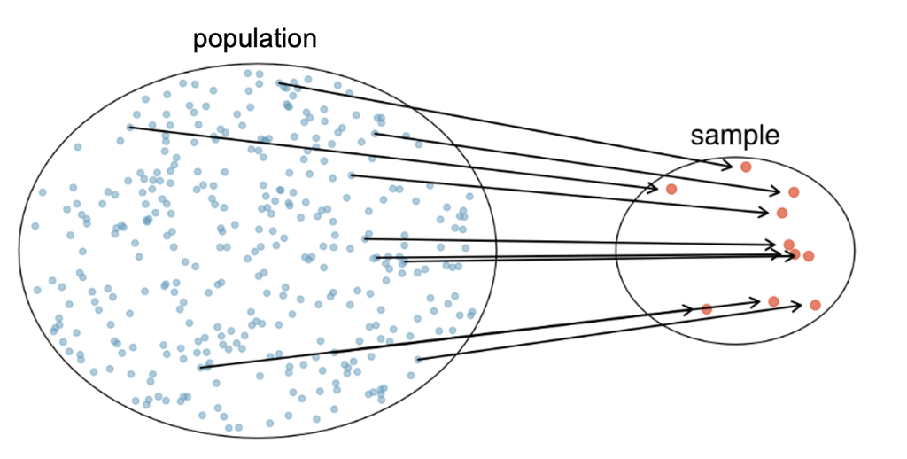

## Probability terminology

- **Event**: a potential outcome
- **Probability** is a measure of how likely it is that an event occurs
- The sum of the probabilities of all events in a **sample space** is 1
- $0 \leq Pr(A) \leq 1$

## Probability definitions

- The **complement** of event $A$ is denoted $A^c$ and it indicates that event $A$ does not occur. $Pr(A) = 1-Pr(A^c)$
- The occurrence of two events $A$ and $B$ at the same time is denoted by $A \cap B$ and $Pr(A\cap B)$ is known as the joint probability of $A$ and $B$
- The event that either $A$ or $B$ or both occur is denoted by $A \cup B$. $Pr(A\cup B) = Pr(A) + Pr(B) - Pr(A \cap B)$
- Mutually exclusive events: $Pr(A\cap B)=0$
- Conditional probability: $Pr(A|B)=\frac{Pr(A\cap B)}{Pr(B)}$

## Independent Events

If knowing about the occurrence of event $A$ does not give information about the probability of event $B$, then events $A$ and $B$ are **independent**.

Mathematically: $Pr(A\cap B) = Pr(A)Pr(B)$

and $Pr(A|B)=Pr(A)$

## Bayes Theorem

Bayes Theorem allows us to invert conditional probabilities. We can use it to update a belief based on prior knowledge.

$Pr(B|A) = \frac{Pr(A|B)Pr(B)}{Pr(A)}$

## Bayes Theorem Example

You have 3 coins. 2 of them are fair and one is rigged so that it always lands on heads. You choose a coin at random and flip it; it lands on heads. Is the coin you chose likely to be fair or rigged?

## Birthday Problem

What is the probability that two people in the class have the same birthday?